# Analyzing Stock Market Data with R

using quantmod from Cran (https://cran.r-project.org/web/packages/quantmod/)

```r
# install.packages('quantmod')
library(quantmod)
```

For various elements have a look at quantmod

```r
?quantmod
```

We’ll use Yahoo here but Google Finance is also supported. Syntax is slightly different. (https://finance.yahoo.com/lookup/)

We’ll call multiple symbols at once by creating a vector of symbols and then pass the basket to the getSymbols function.

```r
symbolBasket <- c('AAPL', 'AMZN', 'BRK-B', 'SPY')
getSymbols(symbolBasket , src='yahoo')
```

```
[1] "AAPL"  "AMZN"  "BRK-B" "SPY"
```

Summary will show us basics; notice we have to use `` for funny charcters.

```r
summary(`BRK-B`)
```

```
     Index              BRK-B.Open       BRK-B.High      BRK-B.Low       BRK-B.Close
 Min.   :2007-01-03   Min.   : 45.08   Min.   : 47.7   Min.   : 44.82   Min.   : 46.00
 1st Qu.:2010-02-03   1st Qu.: 78.65   1st Qu.: 79.3   1st Qu.: 77.94   1st Qu.: 78.78
 Median :2013-03-07   Median :102.14   Median :102.7   Median :101.89   Median :102.25
 Mean   :2013-03-06   Mean   :116.22   Mean   :117.0   Mean   :115.31   Mean   :116.20
 3rd Qu.:2016-04-07   3rd Qu.:145.10   3rd Qu.:145.7   3rd Qu.:144.19   3rd Qu.:144.92
 Max.   :2019-05-10   Max.   :224.00   Max.   :224.1   Max.   :221.30   Max.   :223.76
  BRK-B.Volume       BRK-B.Adjusted
 Min.   :   175000   Min.   : 46.00
 1st Qu.:  2240325   1st Qu.: 78.78
 Median :  3295750   Median :102.25
 Mean   :  3707453   Mean   :116.20
 3rd Qu.:  4388225   3rd Qu.:144.92
 Max.   :316134200   Max.   :223.76
```

### Data Prep - CLEANUP is never ending

NOTE: BRK-B IS ODD so we cannot get away from data prep ;-) ‘rename’ the object BRK-B to BRKB, not really rename but in essence. Then change names of ‘names’ in new BRKB object

```r
BRKB <- as.xts(`BRK-B`)
names(BRKB)
```

```
[1] "BRK-B.Open"     "BRK-B.High"     "BRK-B.Low"      "BRK-B.Close"    "BRK-B.Volume"
[6] "BRK-B.Adjusted"
```

```r
names(BRKB) <- c("BRKB.Open"   ,  "BRKB.High"   ,  "BRKB.Low"   ,   "BRKB.Close"  ,  "BRKB.Volume",  "BRKB.Adjusted")
names(BRKB)
```

```
[1] "BRKB.Open"     "BRKB.High"     "BRKB.Low"      "BRKB.Close"    "BRKB.Volume"
[6] "BRKB.Adjusted"
```

### Charting begins here

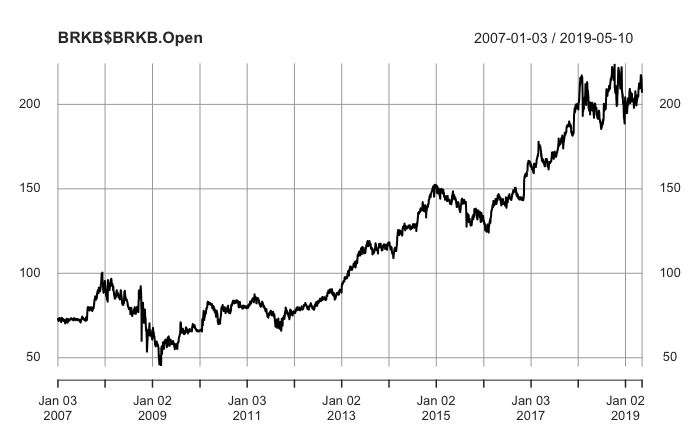

```r
plot(BRKB$BRKB.Open)
```

To view some variation on this a bit we can use this code;

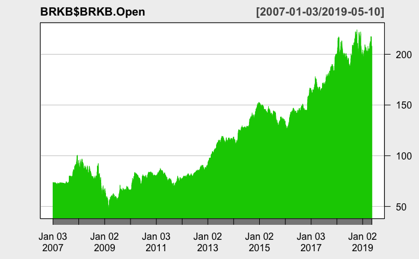

```r
lineChart(BRKB$BRKB.Open, line.type = 'h', theme = 'white', TA = NULL)
```

To see volumes; remove the TA

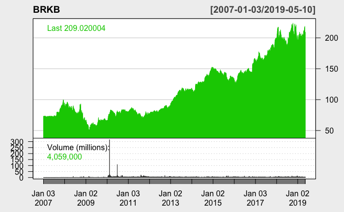

```r
lineChart(BRKB, line.type = 'h', theme = 'white')
```

Barchart, type allows for high, low, close ;)

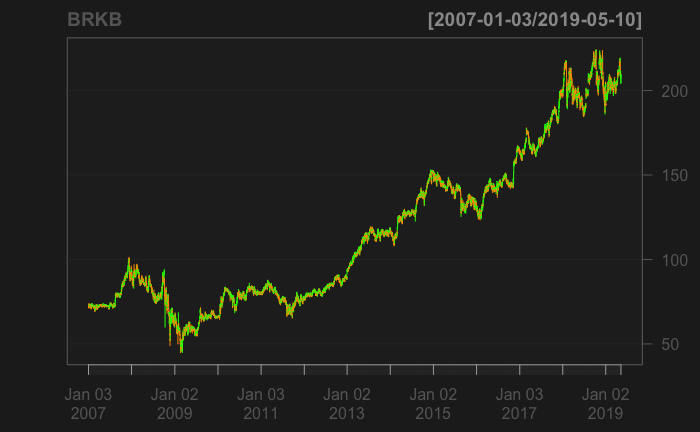

```r
barChart(BRKB, bar.type = 'hlc', TA = NULL)
```

Now just a subset and in candle sticks

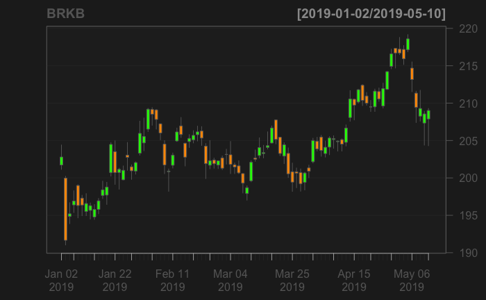

```r
candleChart(BRKB, TA=NULL, subset = '2019')
```

Give a look to candleChart for features;

```r
?candleChart
```

## Not run:

getSymbols(“YHOO”) chartSeries(YHOO) chartSeries(YHOO, subset=‘last 4 months’) chartSeries(YHOO, subset=‘2007::2008-01’) chartSeries(YHOO,theme=chartTheme(‘white’)) chartSeries(YHOO,TA=NULL) #no volume chartSeries(YHOO,TA=c(addVo(),addBBands())) #add volume and Bollinger Bands from TTR

NOTE there are a ton of add… items that are very slick

addMACD() # add MACD indicator to current chart

setTA() chartSeries(YHOO) #draws chart again, this time will all indicators present

## End(Not run)

Add MACD

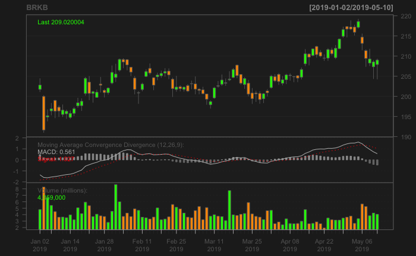

```r
candleChart(BRKB, TA=c(addMACD(),addVo()), subset = '2019')
```

?addMACD

```r
?addMACD()
```

addMACD(fast = 12, slow = 26, signal = 9, type = “EMA”, histogram = TRUE, col)

Various ways to dictate time, in this case everything after… Also added in ADX

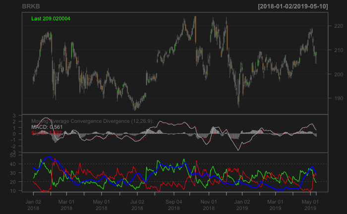

```r
candleChart(BRKB, TA=c(addMACD(),addADX()), subset = '2018-01::')
```

Various ways to dictate time, in this case everything in between… Background is the ‘Theme’

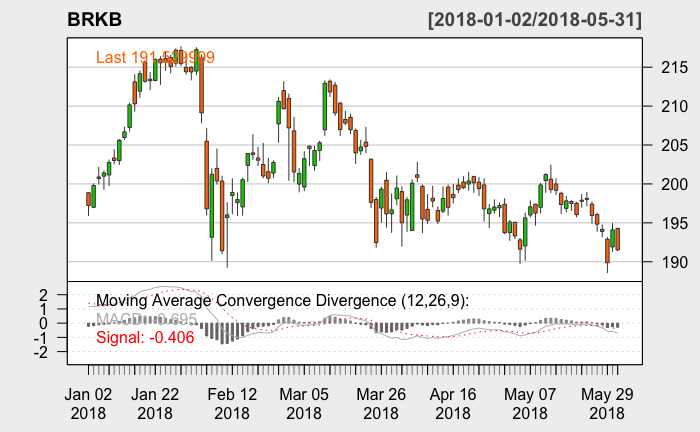

```r
candleChart(BRKB , TA=c(addMACD()), subset = '2018-01::2018-05', theme = 'white')
```

Various options for theme’s overall

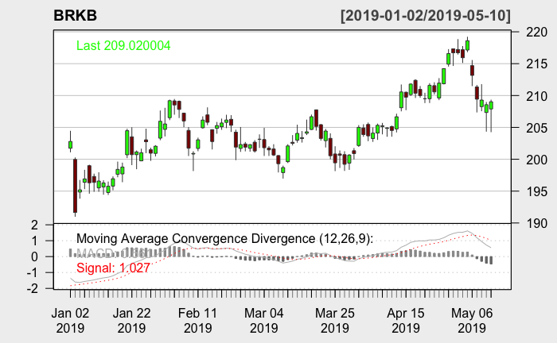

```r
candleChart(BRKB , TA=c(addMACD()), subset = '2019-01::', theme = chartTheme('white', up.col='green',dn.col='darkred'))
```

chartSeries is another cool way to do this same stuff

```r
?chartSeries
```

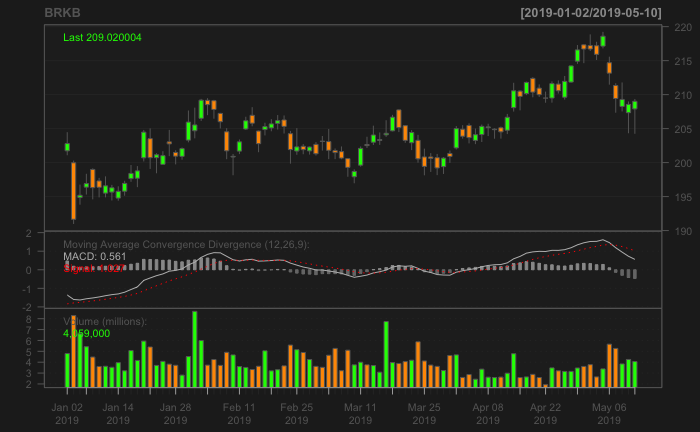

```r
chartSeries(BRKB,
            type = c("auto", "candlesticks"),
            subset = '2019-01::',
            show.grid = TRUE,
            major.ticks='auto', minor.ticks=TRUE,
            TA=c(addMACD(),addVo()))
```

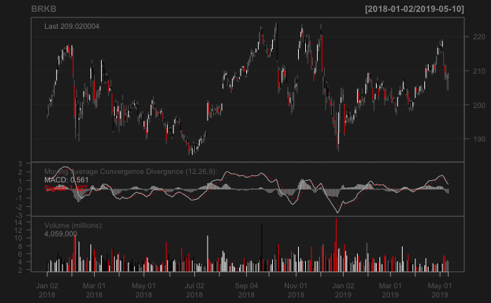

```r
chartSeries(BRKB,
            type = c("auto", "candlesticks"),
            subset = '2018-01::',
            show.grid = TRUE,
            major.ticks='auto', minor.ticks=TRUE,
            multi.col = TRUE,
            TA=c(addMACD(),addVo()))
```

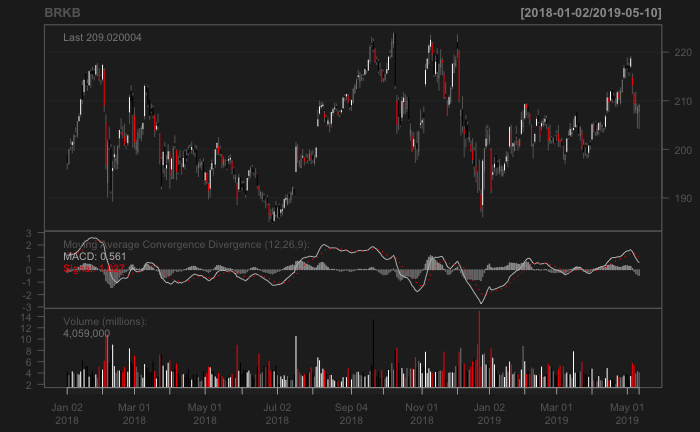

```r
chartSeries(BRKB,
            type = c("auto", "matchsticks"),
            subset = '2018-01::',
            show.grid = TRUE,
            major.ticks='auto', minor.ticks=TRUE,
            multi.col = TRUE,
            TA=c(addMACD(),addVo()))
```

### Adding indicators starts here - although we jumped ahead up above

We’ll use TTR, which is installed with quantmod, if not you can install TTR TTR - Technical Trading Rules So Cool!

```r
?TTR
```

Let’s do a Simple Moving Average

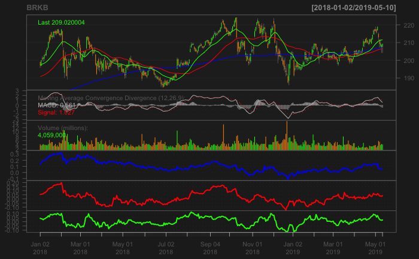

```r
chartSeries(BRKB,
            type = c("auto", "matchsticks"),
            subset = '2018-01::',
            show.grid = TRUE,
            major.ticks='auto', minor.ticks=TRUE,
            multi.col = FALSE,
            TA=c(addMACD(),addVo(),addSMA(n=200,col = 'blue'),addSMA(n=50,col = 'red'),addSMA(n=22,col = 'green'),
            addROC(n=200,col = 'blue'),addROC(n=50,col = 'red'),addROC(n=22,col = 'green'))) # rate of change
```

Bollinger bands Basics; addBBands(n = 20, sd = 2, maType = “SMA”, draw = ‘bands’, on = -1)

```r
?addBBands
```

Experimental BBands “The primary addition to this function call over the TTR version is in the draw argument. ‘bands’ will draw standard Bollinger Bands, ‘percent’ will draw Bollinger %b and ‘width’ will draw Bolinger Bands Width. The last two will be drawn in new figure regions.”

```r
?add_BBands
```

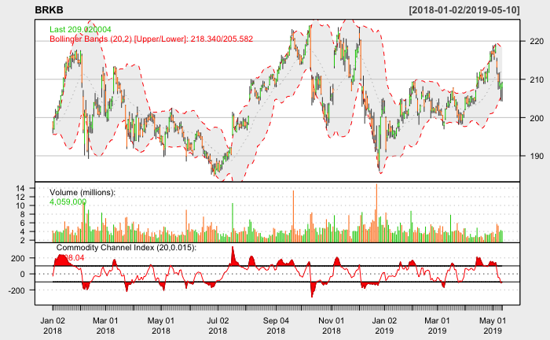

```r
chartSeries(BRKB, theme="white",
 TA="addVo();addBBands();addCCI()", subset = '2018-01::')
```

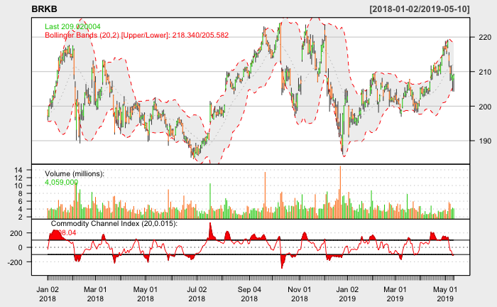

```r
chartSeries(BRKB, theme="white",
 TA="addVo();addBBands();addCCI()", subset = '2018-01::')
```

### Create a Custom Indicator

Start with a simple chart.

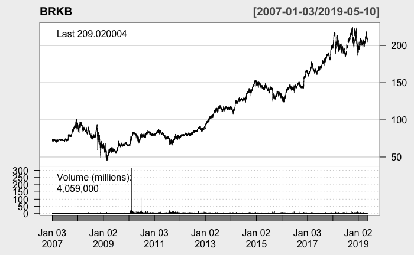

```r
chartSeries(BRKB, theme=chartTheme('white'), up.col="black",
 dn.col="black")
```

BRKB exponential moving averages

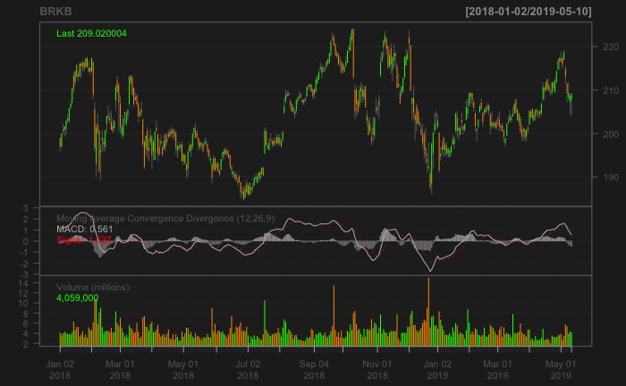

```r
BRKB.EMA.20<- EMA(BRKB$BRKB.Close, n=20)
BRKB.EMA.50<- EMA(BRKB$BRKB.Close, n=50)
BRKB.EMA.100<- EMA(BRKB$BRKB.Close, n=100)
BRKB.EMA.200<- EMA(BRKB$BRKB.Close, n=200)
chartSeries(BRKB,
            type = c("auto", "matchsticks"),
            subset = '2018-01::',
            show.grid = TRUE,
            major.ticks='auto', minor.ticks=TRUE,
            multi.col = FALSE,
            TA=c(addMACD(),addVo()))
```

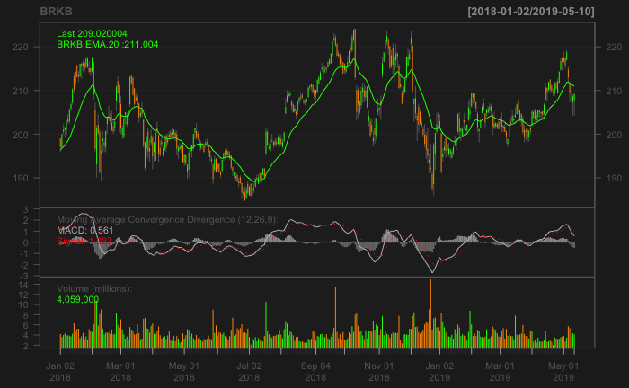

```r
            addTA(BRKB.EMA.20, on=1, col = "green")
```

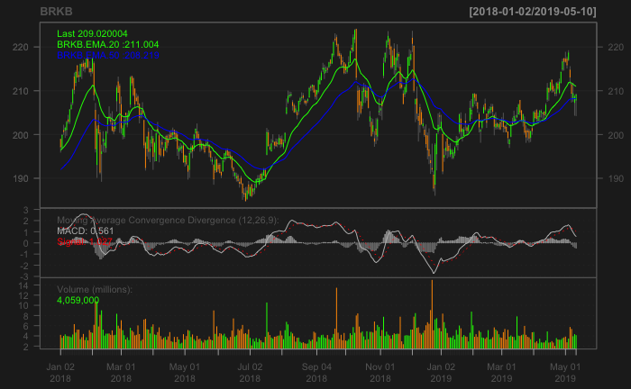

```r
            addTA(BRKB.EMA.50, on=1, col = "blue")
```

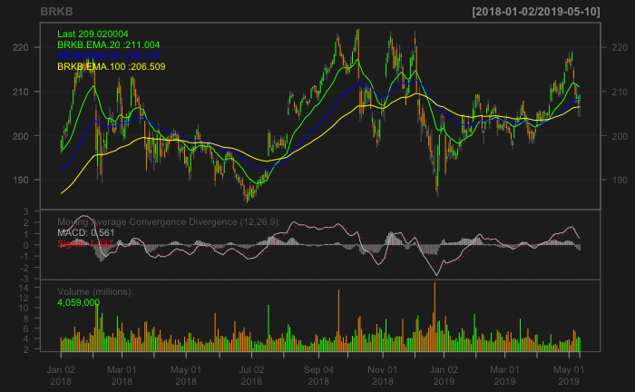

```r
            addTA(BRKB.EMA.100, on=1, col = "yellow")
```

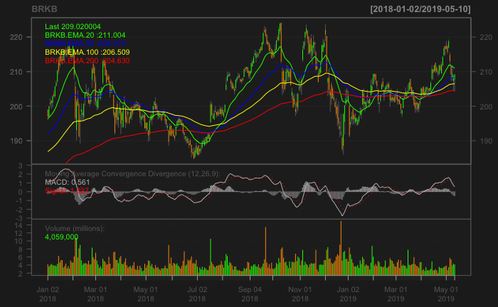

```r
            addTA(BRKB.EMA.200, on=1, col = "red")
```

# # CUSTOM INDICATOR

================== NOTES on Syntax below here two options for code in MarkDown

```r
getSymbols('^GSPC', src='yahoo')
```

```
[1] "^GSPC"
```

```r
getSymbols('^GSPC', src='yahoo')
```

```
[1] "^GSPC"
```